# Group 5 Midterm Project Report

Erika Canda, Shannon Cloherty, Alex Klimek, Tina Teng, Afia Tyus

# Introduction

These data are from a randomized trial that tested whether a milk formula called mF75 improved outcomes for children with severe malnutrition over a regularly used formula (Bandsma et al., 2019). mF75 is low-carbohydrate and lactose free. The authors’ hypothesis was that a low-carb and lactose free formula may reduce instances of diarrhea, carbohydrate malabsorption, and refeeding syndrome. The primary outcome variable is the days to stabilization for children given both standard F75 and modified F75 (mF75). 843 severely malnourished children were enrolled between December 2014 and December 2015 in Kenya and Malawi.

# Summary Statistics

| **Characteristic** | **Overall**, N = 513<sup>1</sup> | **Modified F75 (intervention)**, N = 258<sup>1</sup> | **Standard F75**, N = 255<sup>1</sup> |
| --- | --- | --- | --- |
| Study Site |  |  |  |
| A | 231 (45%) | 115 (45%) | 116 (45%) |
| B | 183 (36%) | 92 (36%) | 91 (36%) |
| C | 99 (19%) | 51 (20%) | 48 (19%) |
| Age in months | 16 (10, 26) | 16 (10, 25) | 17 (10, 26) |
| Sex |  |  |  |
| Female | 244 (48%) | 125 (48%) | 119 (47%) |
| Male | 269 (52%) | 133 (52%) | 136 (53%) |
| Main care giver to the child |  |  |  |
| Grandparent | 21 (4.1%) | 9 (3.5%) | 12 (4.7%) |
| Mother | 478 (93%) | 245 (95%) | 233 (91%) |
| Other | 14 (2.7%) | 4 (1.6%) | 10 (3.9%) |
| Child Still Breastfeeding | 235 (46%) | 124 (48%) | 111 (44%) |
| Unknown | 1 | 1 | 0 |
| Shock requiring fluid | 18 (3.5%) | 6 (2.3%) | 12 (4.7%) |
| Impaired consciousness | 21 (4.1%) | 11 (4.3%) | 10 (3.9%) |
| Severe Pneumonia | 111 (22%) | 57 (22%) | 54 (21%) |
| Diarrhoea | 242 (47%) | 120 (47%) | 122 (48%) |
| Malaria | 45 (8.8%) | 25 (9.7%) | 20 (7.8%) |
| Other Febrile Illness | 166 (32%) | 90 (35%) | 76 (30%) |
| Unknown | 1 | 1 | 0 |
| Known TB (being treated) | 12 (2.3%) | 4 (1.6%) | 8 (3.1%) |
| Chronic cough >\| month | 32 (6.2%) | 15 (5.8%) | 17 (6.7%) |
| Known Sickle Cell Disease |  |  |  |
| No | 513 (100%) | 258 (100%) | 255 (100%) |
| Known congenital or acquired heart disease | 10 (1.9%) | 4 (1.6%) | 6 (2.4%) |
| Known cerebral palsy or severe developmental delay | 75 (15%) | 37 (14%) | 38 (15%) |
| HIV antibody test |  |  |  |
| Negative | 377 (73%) | 188 (73%) | 189 (74%) |
| Positive | 108 (21%) | 52 (20%) | 56 (22%) |
| Unknown | 28 (5.5%) | 18 (7.0%) | 10 (3.9%) |
| Kwashiorkor | 169 (33%) | 84 (33%) | 85 (33%) |

<sup>1</sup> n (%); Median (IQR)

Table 1 shows a summary of demographic factors by intervention arm and in total. These factors include age, sex, breastfeeding status, and presence of various illnesses and conditions.

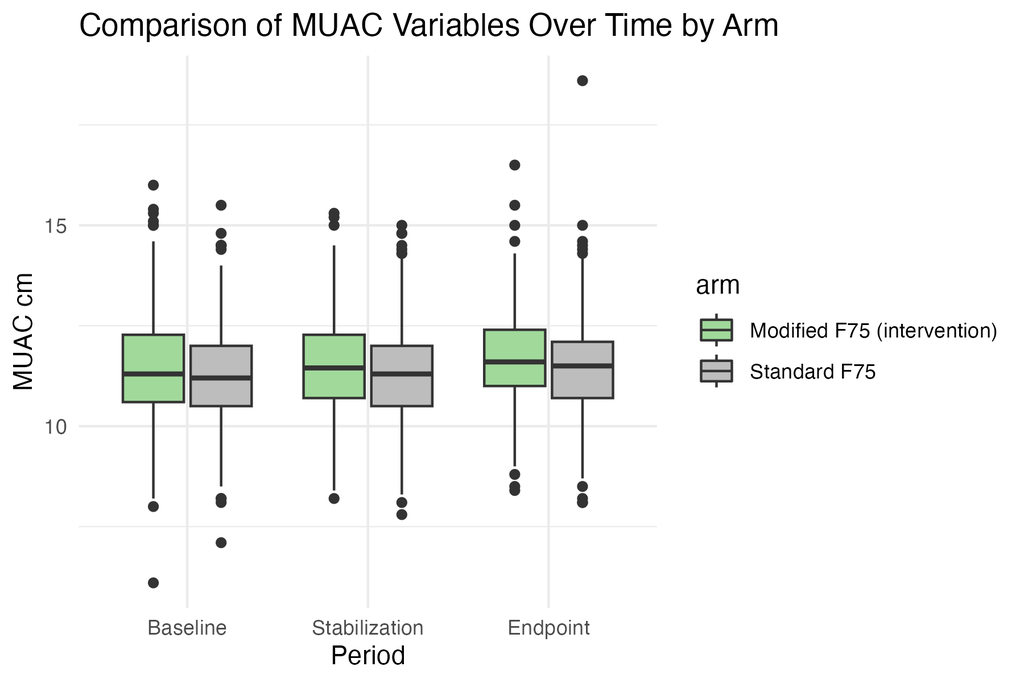

Mid upper arm circumference (MUAC) is used as a criterion for severe acute malnutrition (SAM). MUAC of less than 11.5 cm is indicative of SAM. Here the distribution of MUAC measurements is shown for both the treatment and intervention arms at all three periods where MUAC was measured, baseline, stabilization, and endpoint.

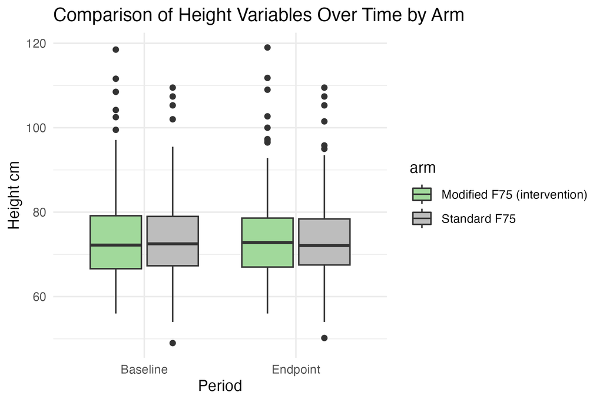

Height is used as a criterion for severe acute malnutrition (SAM) when combined with weight for weight-for-height Z score. Here the distribution of height measurements is shown for both the treatment and intervention arms at baseline and endpoint.

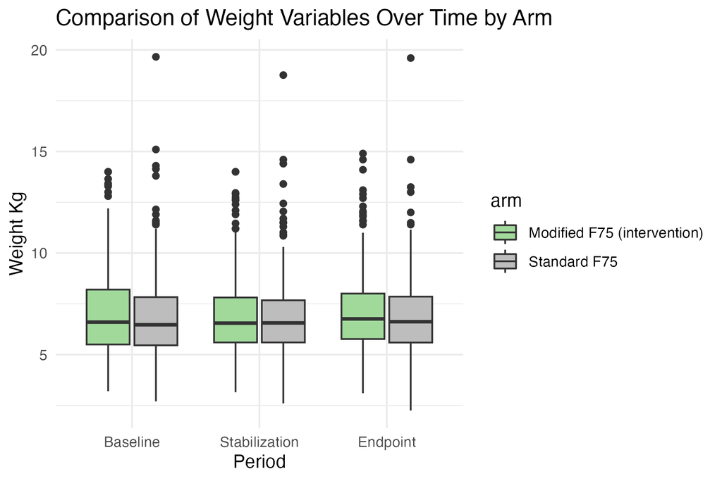

Weight is used as a criterion for severe acute malnutrition (SAM) when combined with height for weight-for-height Z score and BMI. Here the distribution of weight measurements is shown for both the treatment and intervention arms at baseline, stabilization, and endpoint.

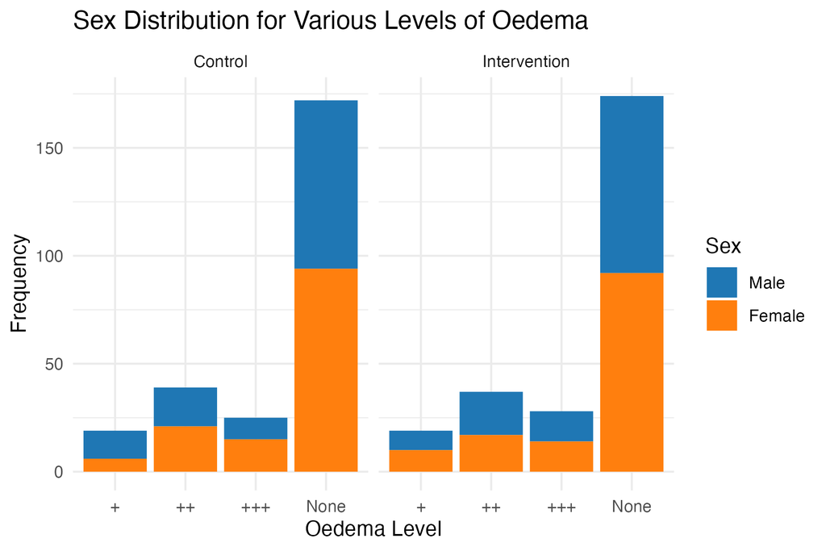

Presence of oedema can be indicative of oedematous malnutrition. Presence of oedematous malnurition of any age was one of the inclusion criteria for this study. The figure shows the distribution of various levels of oedema, separated by sex of the participant. +++ indicates severe generalized bilateral pitting oedema, ++ indicates moderate oedema, and + indicates mild oedema present only on feet or ankles. The authors conducted analyses to determine if presence of oedema was an effect modifier and found no suggestion of modification.

# Linear Regression

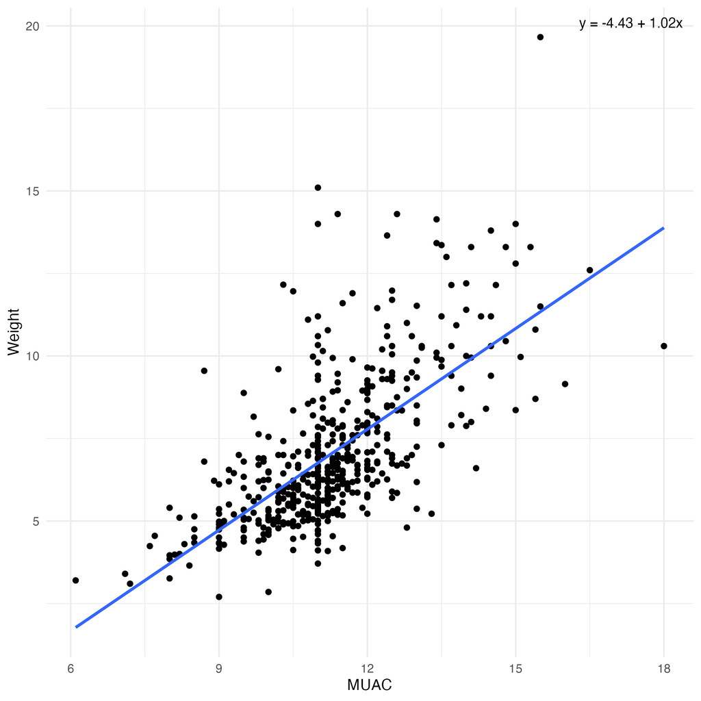

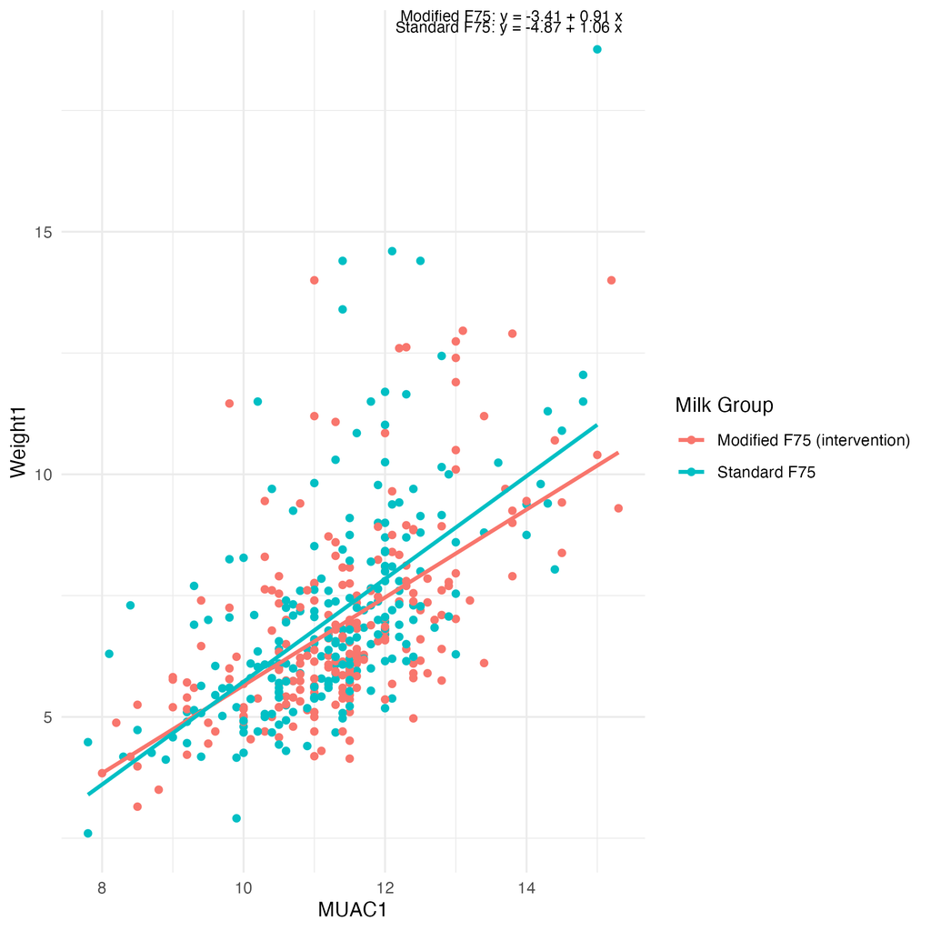

The second regression graph is to show the change of linear relation between the MUAC and weight after the hospitalized severely malnourished children were randomized to receive standard formula (F75) or isocaloric modified F75 (mF75) without lactose and with reduced carbohydrate.

# Days to Stabilization

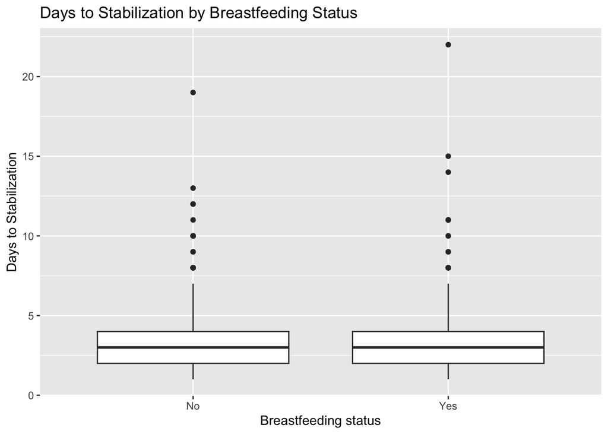

We were curious to see if there was a difference in days to stabilization by breastfeeding status. This figure shows the distribution in days to stabilization by breastfeeding status.

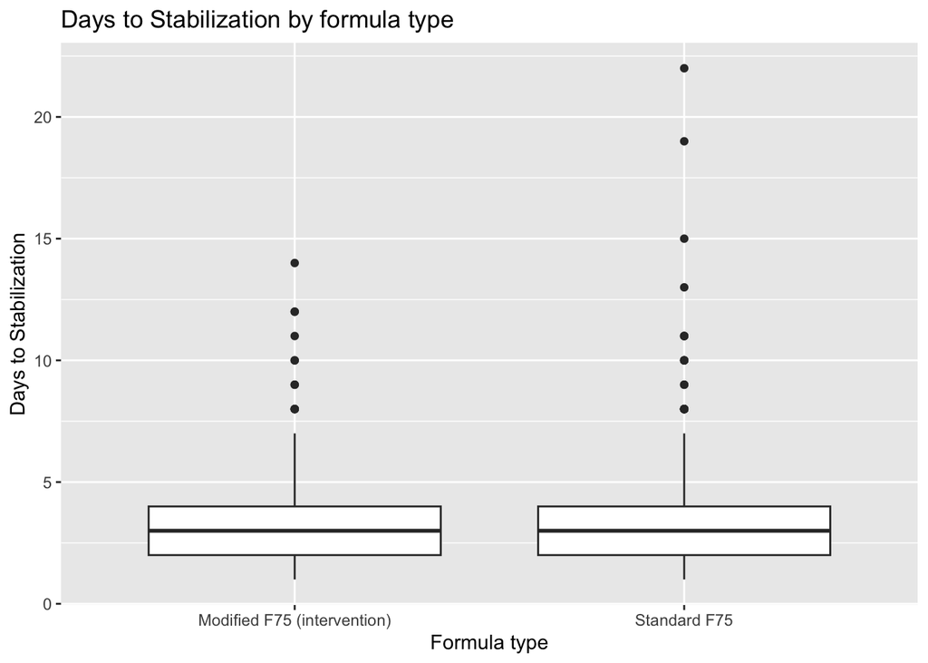

This figure represents the main goal of the study, determining if mF75 affects days to stabilization. The figure visually supports the conclusion of the authors, which was that there was no evidence for difference in time to stabilization (Brandsma et al., 2019).

# Parameterized Figures

```
##
## Greater than or equal to cutoff                Less than cutoff
##                              41                             411
##                            <NA>
##                              61
```

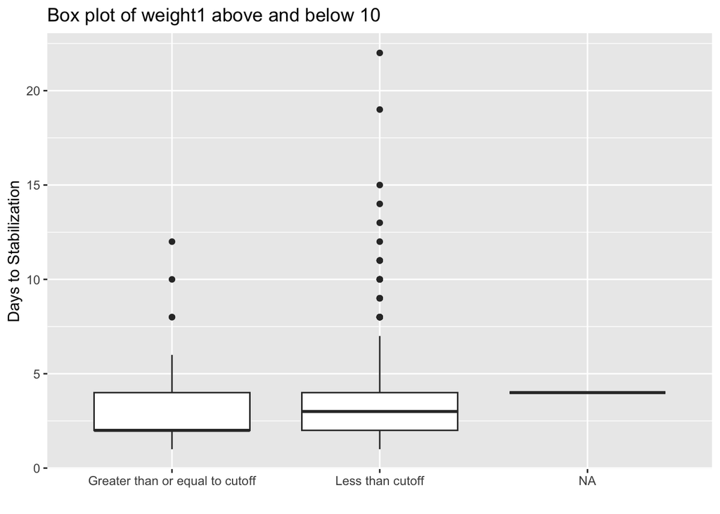

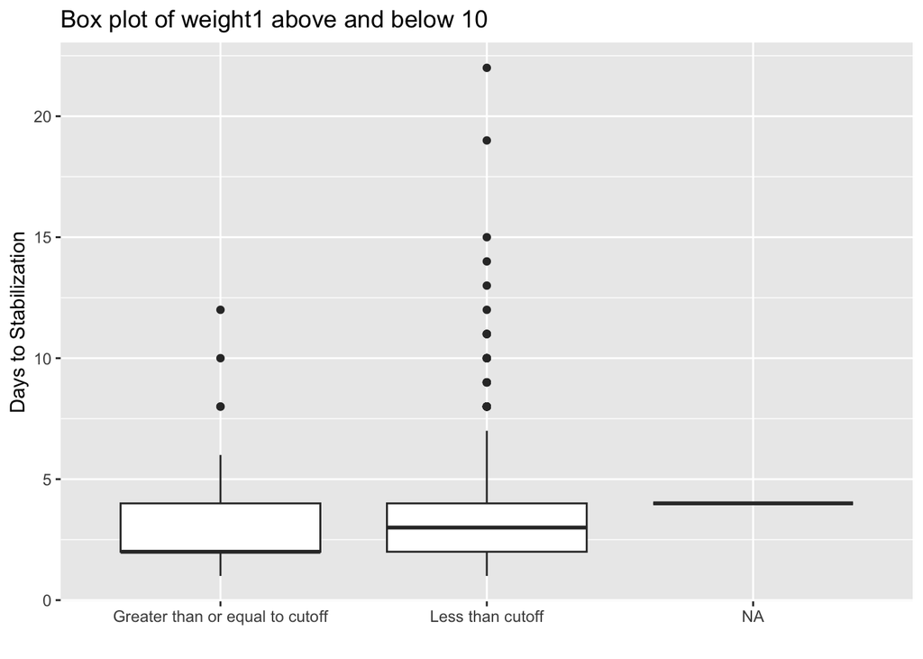

The final graphs are based on the parameters defined at the start of the report. Using the two parameters: var_name and var_cutoff, the user can create a new boxplot comparing their variable of choice with the outcome variable, days to stabilization. The boxplot will then group values above and below the cutoff. The graph above compares the distribution of the days to stabilization with weight1 for those above and below 10.

The median for those greater than or equal to 10 is equal to 2. The median for those less than 10 is equal to 3.